# Eye-Tracking Analysis Workshop

Dan Mirman

23 January 2019

## Workshop Schedule

Day 1: Data wrangling, Pre-processing eye-tracking data

| Time | Content |
| --- | --- |
| 9am - Noon | Part 1: Data wrangling |
| Noon - 1:30pm | Lunch break, Q&A, own data analysis time |
| 1:30pm - 4:30pm | Part 2: Pre-processing eye-tracking data |

Day 2: Statistical analysis of eye-tracking data (GCA)

## Introduction to `tidyverse`

[figure not shown]

https://www.tidyverse.org/

## Introduction to `tidyverse`

`tidyverse` covers the major aspects of *data wrangling* in one integrated suite of packages

- Reading data: `readr`, `readxl` (.xls and .xlsx files), `haven` (SPSS and SAS files)
- Data visualization: `ggplot2`
- Data organization (`tidyr`): `gather()` columns, `spread()` unique values into columns, `separate()` cells in a column into multiple columns
- Data manipulation (`dplyr`): `select()` columns, `filter()` cases, `arrange()` rows in order, `mutate()` variables, `summarize` values
- Programming: `%>%`

## Pipes (`magrittr`)

Easy way to do a series of operations:

`g(f(x, y), z)` is the same as `x %>% f(y) %>% g(z)`

But easier to read and write: “Take `x` then do `f(y)` then do `g(z)`”

## Load the packages

```r
library(tidyverse) # a shortcut that loads the core tidyverse packages
library(gazer) # example data and functions for analyzing eye-tracking data
```

## Reading data

Read a SPSS file

```r
dat <- haven::read_sav("filename.sav")
```

Read an Excel file

```r
dat <- readxl::read_excel("filename.xls",
                          sheet = "Sheet1", # optionally specify a sheet by name or number
                          skip = 2, # optionally skip some header rows
                          range ="C1:E7") # optionally specify a cell range
```

Note: `haven` and `readxl` are part of `tidyverse`, but are not “core” packages, so they need to be installed and loaded separately.

## Manipulating data

```r
summary(NamingRecovery)
```

```
##    SubjectID       Diagnosis     TestTime    Correct
##  NR001  : 5   Anomic    :30   Min.   :0   Min.   :0.0227
##  NR002  : 5   Conduction:45   1st Qu.:1   1st Qu.:0.4136
##  NR003  : 5   Wernicke  :40   Median :2   Median :0.7278
##  NR004  : 5                   Mean   :2   Mean   :0.6310
##  NR005  : 5                   3rd Qu.:3   3rd Qu.:0.8850
##  NR006  : 5                   Max.   :4   Max.   :0.9942
##  (Other):85
##  Semantic.error    Mixed.error       Formal.error    Unrelated.error
##  Min.   :0.0000   Min.   :0.00000   Min.   :0.0000   Min.   :0.0000
##  1st Qu.:0.0146   1st Qu.:0.00695   1st Qu.:0.0174   1st Qu.:0.0000
##  Median :0.0235   Median :0.01790   Median :0.0578   Median :0.0060
##  Mean   :0.0354   Mean   :0.02215   Mean   :0.0881   Mean   :0.0606
##  3rd Qu.:0.0492   3rd Qu.:0.02940   3rd Qu.:0.1383   3rd Qu.:0.0656
##  Max.   :0.2000   Max.   :0.08780   Max.   :0.3778   Max.   :0.3540
##
##  Nonword.error
##  Min.   :0.0000
##  1st Qu.:0.0495
##  Median :0.1279
##  Mean   :0.1627
##  3rd Qu.:0.2247
##  Max.   :0.6518
##
```

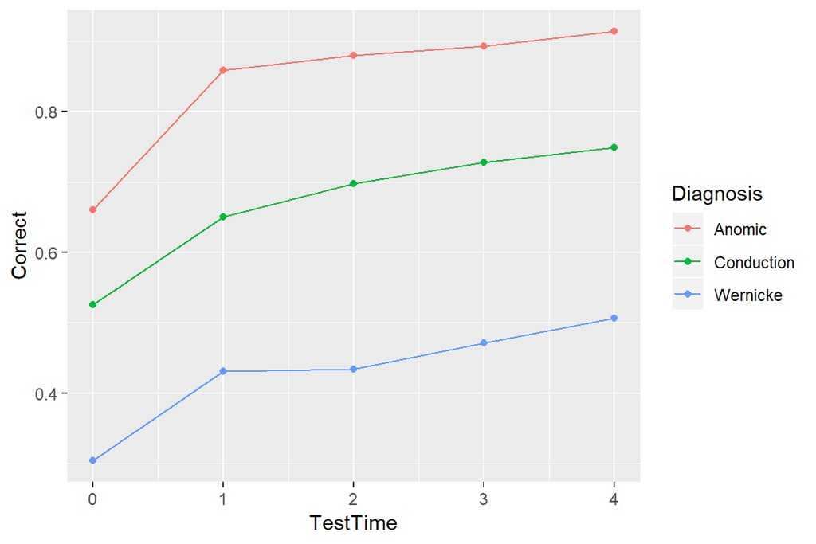

```r
ggplot(NamingRecovery, aes(TestTime, Correct, color=Diagnosis)) +
  stat_summary(fun.y=mean, geom="line") +
  stat_summary(fun.y=mean, geom="point")
```

## Manipulating data

For each of the five test times, calculate the overall average accuracy.

```r
NamingRecovery %>%
  group_by(TestTime) %>%
  summarize(Accuracy = mean(Correct))
```

```
## # A tibble: 5 x 2
##   TestTime Accuracy
##      <dbl>    <dbl>
## 1        0    0.484
## 2        1    0.628
## 3        2    0.653
## 4        3    0.682
## 5        4    0.708
```

## Manipulating data

Calculate the overall accuracy for each aphasia sub-type group.

```r
NamingRecovery %>%
  group_by(Diagnosis) %>%
  summarize(Accuracy = mean(Correct))
```

```
## # A tibble: 3 x 2
##   Diagnosis  Accuracy
##   <fct>         <dbl>
## 1 Anomic        0.841
## 2 Conduction    0.670
## 3 Wernicke      0.429
```

## Manipulating data

Calculate the average accuracy for each test time separately for each aphasia sub-type group

```r
NamingRecovery %>%
  group_by(Diagnosis, TestTime) %>%
  summarize(Accuracy = mean(Correct))
```

```
## # A tibble: 15 x 3
## # Groups:   Diagnosis [?]
##    Diagnosis  TestTime Accuracy
##    <fct>         <dbl>    <dbl>
##  1 Anomic            0    0.661
##  2 Anomic            1    0.859
##  3 Anomic            2    0.880
##  4 Anomic            3    0.893
##  5 Anomic            4    0.914
##  6 Conduction        0    0.526
##  7 Conduction        1    0.650
##  8 Conduction        2    0.698
##  9 Conduction        3    0.728
## 10 Conduction        4    0.749
## 11 Wernicke          0    0.304
## 12 Wernicke          1    0.431
## 13 Wernicke          2    0.433
## 14 Wernicke          3    0.471
## 15 Wernicke          4    0.507
```

## Manipulating data

Calculate the average accuracy for each test time separately for each aphasia sub-type group, and make a nice table.

```r
NamingRecovery %>%
  group_by(Diagnosis, TestTime) %>%
  summarize(Accuracy = mean(Correct)) %>%
  spread(key = Diagnosis, value = Accuracy)
```

```
## # A tibble: 5 x 4
##   TestTime Anomic Conduction Wernicke
##      <dbl>  <dbl>      <dbl>    <dbl>
## 1        0  0.661      0.526    0.304
## 2        1  0.859      0.650    0.431
## 3        2  0.880      0.698    0.433
## 4        3  0.893      0.728    0.471
## 5        4  0.914      0.749    0.507
```

## Organizing data: `spread()`

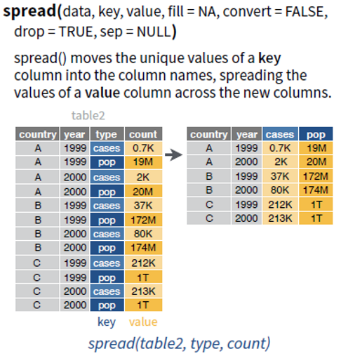

https://github.com/rstudio/cheatsheets/raw/master/data-import.pdf

## Organizing data: `tidyr`

*Tidy* data: Every column is a variable, every row is an observation

```r
head(NamingRecovery)
```

```
##   SubjectID  Diagnosis TestTime Correct Semantic.error Mixed.error
## 1     NR001 Conduction        0  0.8313         0.0688      0.0250
## 3     NR002 Conduction        0  0.7679         0.0357      0.0357
## 4     NR003 Conduction        0  0.0368         0.0441      0.0294
## 5     NR004   Wernicke        0  0.1357         0.0643      0.0429
## 6     NR005 Conduction        0  0.8526         0.0385      0.0256
## 7     NR006     Anomic        0  0.8158         0.0614      0.0614
##   Formal.error Unrelated.error Nonword.error
## 1       0.0125          0.0063        0.0563
## 3       0.0238          0.0060        0.1310
## 4       0.3382          0.3529        0.1985
## 5       0.1643          0.2714        0.3214
## 6       0.0128          0.0064        0.0641
## 7       0.0351          0.0175        0.0088
```

- Each row is a testing occasion: participant `i` at test time `j`. Are these data “tidy”?
- Yes: an observation is one administration of the naming test
- No: the test produces mutliple measures (`Correct`, `Semantic.error`, `Mixed.error`, etc.), each of those is a separate observation.

## Organizing data: `gather()`

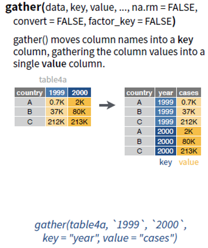

https://github.com/rstudio/cheatsheets/raw/master/data-import.pdf

## Organizing data: `gather()`

```r
NR.g <- gather(NamingRecovery,
               key="ResponseType", value="Proportion",
               "Correct", "Semantic.error", "Mixed.error", # instead could use 4:9
                 "Formal.error", "Unrelated.error", "Nonword.error")
head(NR.g)
```

```
##   SubjectID  Diagnosis TestTime ResponseType Proportion
## 1     NR001 Conduction        0      Correct     0.8313
## 2     NR002 Conduction        0      Correct     0.7679
## 3     NR003 Conduction        0      Correct     0.0368
## 4     NR004   Wernicke        0      Correct     0.1357
## 5     NR005 Conduction        0      Correct     0.8526
## 6     NR006     Anomic        0      Correct     0.8158
```

## Organizing data: `gather()`

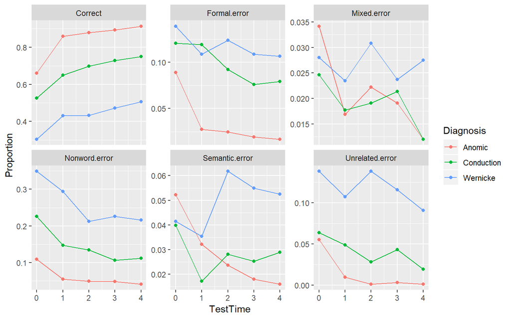

```r
ggplot(NR.g, aes(TestTime, Proportion, color=Diagnosis)) +
  facet_wrap(~ ResponseType, scales = "free_y") +
  stat_summary(fun.y=mean, geom="line") +
  stat_summary(fun.y=mean, geom="point")
```

## Exercise

The `USArrests` data set contains violent crime arrests (per 100,000 residents) in each of the 50 states in the USA in 1973 and the percent of the population of each state that lived in urban areas.

```r
summary(USArrests)
```

```
##      Murder         Assault       UrbanPop         Rape
##  Min.   : 0.80   Min.   : 45   Min.   :32.0   Min.   : 7.3
##  1st Qu.: 4.08   1st Qu.:109   1st Qu.:54.5   1st Qu.:15.1
##  Median : 7.25   Median :159   Median :66.0   Median :20.1
##  Mean   : 7.79   Mean   :171   Mean   :65.5   Mean   :21.2
##  3rd Qu.:11.25   3rd Qu.:249   3rd Qu.:77.8   3rd Qu.:26.2
##  Max.   :17.40   Max.   :337   Max.   :91.0   Max.   :46.0
```

A. Convert the `USArrests` data set from a wide to a long format so that instead of separate variables for each crime type (Murder, Assault, Rape), there is one variable that identifies the crime type and one variable that contains the rates for each crime type for each state.

B. Make a scatterplot showing the relationship between each type of violent crime rate and percent of population living in urban areas.

## Exercise Solution

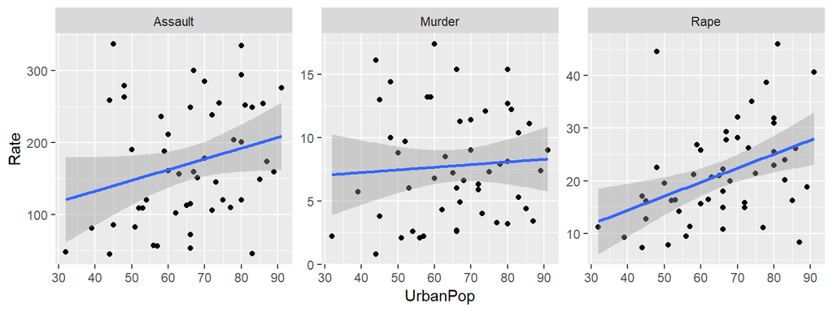

```r
# A. Convert the USArrests data set from a wide to a long format
x <- gather(USArrests, key="CrimeType", value="Rate",
            Murder, Assault, Rape)
# B. Make a scatterplot showing each type of violent crime rate and percent urban population
ggplot(x, aes(UrbanPop, Rate)) +
  facet_wrap(~ CrimeType, scales="free", nrow=1) +
  geom_point() + stat_smooth(method="lm")
```

## Merging related data

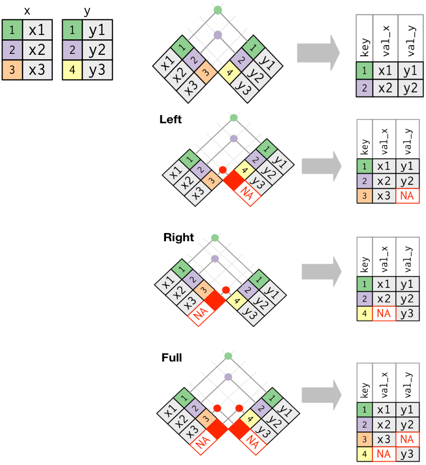

## Merging related data

`base::merge()` and `dplyr::*join()` do the same things. `*join` is supposed to be faster and doesn’t mess with the order of the rows. (But I’m used to the syntax of `merge()`, so that’s what I use).

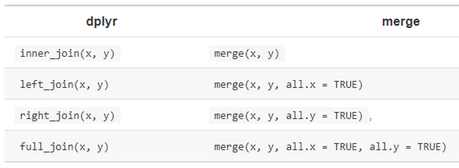

By default, both `merge()` and `*join()` will use columns with identical names as the “key” variables for aligning data elements. If the variables do not have identical names (e.g., `Participant` - `ParticipantID`), use the `by` argument to specify matching variables.

## Subsetting data

- `base::subset()`
- `dplyr::filter()`, `dplyr::select()`

Example: from `NamingRecovery` get just the baseline accuracy and formal errors for participants with Conduction aphasia.

```r
# base
NR.s <- subset(NamingRecovery, Diagnosis == "Conduction" & TestTime == 0,
               select = c("SubjectID", "Diagnosis", "TestTime", "Correct", "Formal.error"))
NR.s
```

```
##    SubjectID  Diagnosis TestTime Correct Formal.error
## 1      NR001 Conduction        0  0.8313       0.0125
## 3      NR002 Conduction        0  0.7679       0.0238
## 4      NR003 Conduction        0  0.0368       0.3382
## 6      NR005 Conduction        0  0.8526       0.0128
## 10     NR009 Conduction        0  0.1386       0.1627
## 15    NR0013 Conduction        0  0.6023       0.1345
## 82    NR0019 Conduction        0  0.3050       0.1915
## 85    NR0022 Conduction        0  0.7627       0.0339
## 86    NR0023 Conduction        0  0.4348       0.1739
```

```r
# dplyr
NR.s <- NamingRecovery %>%
  filter(Diagnosis == "Conduction" & TestTime == 0) %>%
  select(SubjectID, Diagnosis, TestTime, Correct, Formal.error)
NR.s
```

```
##   SubjectID  Diagnosis TestTime Correct Formal.error
## 1     NR001 Conduction        0  0.8313       0.0125
## 2     NR002 Conduction        0  0.7679       0.0238
## 3     NR003 Conduction        0  0.0368       0.3382
## 4     NR005 Conduction        0  0.8526       0.0128
## 5     NR009 Conduction        0  0.1386       0.1627
## 6    NR0013 Conduction        0  0.6023       0.1345
## 7    NR0019 Conduction        0  0.3050       0.1915
## 8    NR0022 Conduction        0  0.7627       0.0339
## 9    NR0023 Conduction        0  0.4348       0.1739
```

## Separate one column into multiple columns

Useful when you have values that are actually multiple distinct pieces of information stuck together.

```r
dat <- data.frame(Condition = paste(rep(c("A", "B"), 3), rep(1:3, each=2), sep="_"))
dat
```

```
##   Condition
## 1       A_1
## 2       B_1
## 3       A_2
## 4       B_2
## 5       A_3
## 6       B_3
```

```r
#dat %>% separate(Condition, into=c("Factor1", "Factor2"), sep="_")
separate(dat, Condition, into=c("Factor1", "Factor2"), sep="_")
```

```
##   Factor1 Factor2
## 1       A       1
## 2       B       1
## 3       A       2
## 4       B       2
## 5       A       3
## 6       B       3
```

## Data transformations: `dplyr::mutate()`

`mutate()` is similar to `summarize()`, but returns a transformation of the data (same size) rather than a summary (one value).

Example: Convert each participant’s accuracy to proportion change from their baseline accuracy.

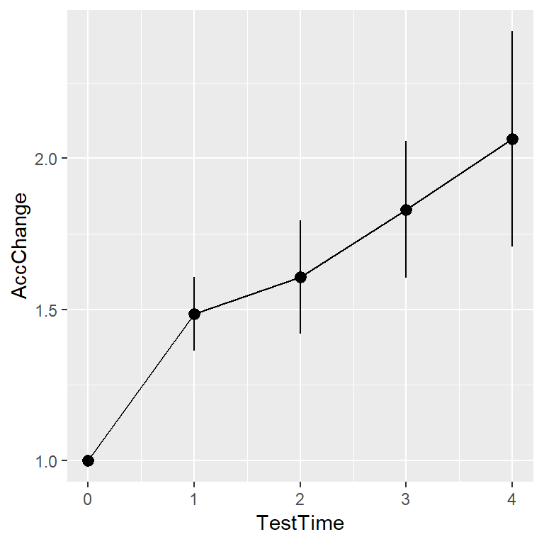

```r
ex <- NamingRecovery %>%
  group_by(SubjectID) %>%
  mutate(AccChange = Correct/Correct[TestTime == 0])
#summary(ex)
ggplot(ex, aes(TestTime, AccChange)) +
  stat_summary(fun.y=mean, geom="line") +
  stat_summary(fun.data=mean_se, geom="pointrange")
```

## Writing functions

**DRY: Don’t Repeat Yourself**

Some additional general principles:

- Naming conventions
  - Avoid over-writing existing functions. Tip: to check if a function name already exists use `?function_name`
  - Use sensible names: e.g., `action_argument` or `target_action`
- Comment your code; use special comments to organize code into chunks
- Insert `print` statements for debugging and monitoring

## Function arguments

`fun_name <- function(arg1, arg2, ..., arg_def=0){...}`

- Try to make sure that everything the function needs will be provided in the input
  - Environment and scoping: the function environment is (somewhat) isolated from your main workspace environment.
  - Good: intermediate steps and variables inside your function don’t clutter up your enviornment.
  - Danger: function shouldn’t rely on knowing anything other than its own arguments.
  - Arguments can be optional if you give them default values
- `return` the result

```r
addTwo <- function(x){
  result <- x+2
  return(result)
}
addTwo(10)
```

```
## [1] 12
```

## Exercise: Fibonacci function

Fibonacci sequence: $F_n = F_{n-1} + F_{n-2}$

$1, 1, 2, 3, 5, 8, 13, 21, 34, 55, ...$

Can be calculated using a `for` loop:

```r
fib <- c(1,1)
for(n in 3:100){
  fib[n] <- fib[n-1] + fib[n-2]
}
fib[1:15]
```

```
##  [1]   1   1   2   3   5   8  13  21  34  55  89 144 233 377 610
```

Write a function that takes one argument (`x`) and produces the first `x` digits of the Fibonacci sequence.

## Exercise Solution

Write a function that takes one argument (`x`) and produces the first `x` digits of the Fibonacci sequence: $F_n = F_{n-1} + F_{n-2}$.

```r
fib_fun <- function(x){
  fib <- c(1,1)
  for(i in 3:x){
    fib[i] <- fib[i-1] + fib[i-2]
  }
  return(fib)
}
fib_fun(15)
```

```
##  [1]   1   1   2   3   5   8  13  21  34  55  89 144 233 377 610
```

## More about `tidyverse` and R programming

[figure not shown]

R for Data Science

Read it online for free: https://r4ds.had.co.nz/

Check out RStudio Cheat Sheets: https://www.rstudio.com/resources/cheatsheets/